# LogisticRegression-GradientDescent-Tensorflow

## LOGISTIC REGRESSION WITH TENSORFLOW

### Objective for this Notebook

Created on JupyterLab

Logistic Regression is one of most important techniques in data science. It is usually used to solve the classic classification problem.

**This lesson covers the following concepts of Logistics Regression:**

## Table of Contents

1. Linear Regression vs Logistic Regression
2. Utilizing Logistic Regression in TensorFlow
3. Training

## What is different between Linear and Logistic Regression?

While Linear Regression is suited for estimating continuous values (e.g. estimating house price), it is not the best tool for predicting the class in which an observed data point belongs. In order to provide estimate for classification, we need some sort of guidance on what would be the **most probable class** for that data point. For this, we use **Logistic Regression**.

**Recall linear regression:**
Linear regression finds a function that relates a continuous dependent variable, *y*, to some predictors (independent variables *x1*, *x2*, etc.). Simple linear regression assumes a function of the form:
$$ y = w0 + w1 \times x1 + w2 \times x2 + \cdots $$
and finds the values of *w0*, *w1*, *w2*, etc. The term *w0* is the "intercept" or "constant term" (it's shown as *b* in the formula below):
$$ Y = W X + b $$

Logistic Regression is a variation of Linear Regression, useful when the observed dependent variable, *y*, is categorical. It produces a formula that predicts the probability of the class label as a function of the independent variables.

Despite the name logistic *regression*, it is actually a **probabilistic classification** model. Logistic regression fits a special s-shaped curve by taking the linear regression and transforming the numeric estimate into a probability with the following function:

$$ ProbabilityOfaClass = \theta(y) = \frac{e^y}{1 + e^y} = exp(y) / (1 + exp(y)) = p $$

which produces p-values between 0 (as y approaches minus infinity $-\infty$) and 1 (as y approaches plus infinity $+\infty$). This now becomes a special kind of non-linear regression.

In this equation, *y* is the regression result (the sum of the variables weighted by the coefficients), `exp` is the exponential function and $\theta(y)$ is the [logistic function](http://en.wikipedia.org/wiki/Logistic_function), also called logistic curve. It is a common "S" shape (sigmoid curve), and was first developed for modeling population growth.

You might also have seen this function before, in another configuration:

$$ ProbabilityOfaClass = \theta(y) = \frac{1}{1+e^{-y}} $$

So, briefly, Logistic Regression passes the input through the logistic/sigmoid function but then treats the result as a probability:

[figure not shown]

## Utilizing Logistic Regression in TensorFlow

We begin by installing TensorFlow version 2.9.0 and its required prerequistes.

```python
#!pip install grpcio==1.24.3
#!pip install tensorflow==2.9.0
#!pip install --upgrade scikit-learn numpy
```

**Restart kernel for latest version of TensorFlow to be activated, then continue to the next step.**

For us to utilize Logistic Regression in TensorFlow, we first need to import the required libraries. To do so, you can run the code cell below.

```python
import tensorflow as tf
import pandas as pd
import numpy as np
import time
from sklearn.datasets import load_iris
from sklearn.model_selection import train_test_split
import matplotlib.pyplot as plt
```

[output not shown]

```python
if not tf.__version__ == '2.9.0':
    print(tf.__version__)
    raise ValueError('please upgrade to TensorFlow 2.9.0, or restart your Kernel (Kernel->Restart & Clear Output)')
```

IMPORTANT! => Please restart the kernel by clicking on "Kernel"->"Restart and Clear Outout" and wait until all output disapears. Then your changes will be picked up.

After you have restarted the kernel, re-run the previous two cells to import the libraries properly and then continue to the next section.

Next, we will load the dataset we are going to use. In this case, we are utilizing the `iris` dataset, which is inbuilt -- so there's no need to do any preprocessing and we can jump right into manipulating it. We separate the dataset into *xs* and *ys*, and then into training *xs* and *ys* and testing *xs* and *ys*, (pseudo)randomly.

### Understanding the Data

#### `Iris Dataset`:

This dataset was introduced by British Statistician and Biologist Ronald Fisher, it consists of 50 samples from each of three species of Iris (Iris setosa, Iris virginica and Iris versicolor). In total it has 150 records under five attributes - petal length, petal width, sepal length, sepal width and species. [Dataset source](https://archive.ics.uci.edu/ml/datasets/iris)

Attributes Independent Variable

- petal length
- petal width
- sepal length
- sepal width

Dependent Variable

- Species
  - Iris setosa
  - Iris virginica
  - Iris versicolor

```python
iris = load_iris()
iris_X, iris_y = iris.data[:-1,:], iris.target[:-1]
iris_y= pd.get_dummies(iris_y).values
trainX, testX, trainY, testY = train_test_split(iris_X, iris_y, test_size=0.33, random_state=42)
```

Now we define x and y. These variables will hold our iris data (both the features and label matrices) We also need to give them shapes which correspond to the shape of our data.

```python
# numFeatures is the number of features in our input data.
# In the iris dataset, this number is '4'.
numFeatures = trainX.shape[1]
print('numFeatures is : ', numFeatures )
# numLabels is the number of classes our data points can be in.
# In the iris dataset, this number is '3'.
numLabels = trainY.shape[1]
print('numLabels is : ', numLabels )

#X = tf.Variable( np.identity(numFeatures), tf.TensorShape(numFeatures),dtype='float32') # Iris has 4 features, so X is a tensor to hold our data.
#yGold = tf.Variable(np.array([1,1,1]),shape=tf.TensorShape(numLabels),dtype='float32') # This will be our correct answers matrix for 3 classes.
```

```
numFeatures is :  4
numLabels is :  3
```

```python
trainX = tf.constant(trainX, dtype='float32')
trainY = tf.constant(trainY, dtype='float32')
testX = tf.constant(testX, dtype='float32')
testY = tf.constant(testY, dtype='float32')
```

[output not shown]

### Set model weights and bias

Much like Linear Regression, we need a shared variable weight matrix for Logistic Regression. We initialize both `W` and `b` as tensors full of zeros. Since we are going to learn `W` and `b`, their initial value does not matter too much. These variables are the objects which define the structure of our regression model, and we can save them after they have been trained so we can reuse them later.

We define two TensorFlow variables as our parameters. These variables will hold the weights and biases of our logistic regression and they will be continually updated during training.

Notice that `W` has a shape of [4, 3] because we want to multiply the 4-dimensional input vectors by it to produce 3-dimensional vectors of evidence for the difference classes. `b` has a shape of [3] so we can add it to the output. TensorFlow variables need to be initialized with values, e.g. with zeros.

```python
W = tf.Variable(tf.zeros([4, 3]))  # 4-dimensional input and  3 classes
b = tf.Variable(tf.zeros([3])) # 3-dimensional output [0,0,1],[0,1,0],[1,0,0]
```

```python
#Randomly sample from a normal distribution with standard deviation .01

weights = tf.Variable(tf.random.normal([numFeatures,numLabels],
                                       mean=0.,
                                       stddev=0.01,
                                       name="weights"),dtype='float32')


bias = tf.Variable(tf.random.normal([1,numLabels],
                                    mean=0.,
                                    stddev=0.01,
                                    name="bias"))
```

### Logistic Regression model

We now define our operations in order to properly run the Logistic Regression. Logistic regression is typically thought of as a single equation:

$$ ŷ =sigmoid(WX+b) $$

However, for the sake of clarity, we can have it broken into its three main components:

- a weight times features matrix multiplication operation,
- a summation of the weighted features and a bias term,
- and finally the application of a sigmoid function.

As such, you will find these components defined as three separate operations below.

```python
# Three-component breakdown of the Logistic Regression equation.
# Note that these feed into each other.
def logistic_regression(x):
    apply_weights_OP = tf.matmul(x, weights, name="apply_weights")
    add_bias_OP = tf.add(apply_weights_OP, bias, name="add_bias")
    activation_OP = tf.nn.sigmoid(add_bias_OP, name="activation")
    return activation_OP
```

As we have seen before, the function we are going to use is the *logistic function* $(\frac{1}{1+e^{-Wx}})$, which is fed the input data after applying weights and bias. In TensorFlow, this function is implemented as the `nn.sigmoid` function. Effectively, this fits the weighted input with bias into a 0-100 percent curve, which is the probability function we want.

## Training

**What tells us that our model is bad?**  
The Cost or Loss of the model, so what we want is to minimize that.

### Cost function

Before defining our cost function, we need to define how long we are going to train and how should we define the learning rate.

```python
# Number of Epochs in our training
numEpochs = 700

# Defining our learning rate iterations (decay)
learningRate = tf.keras.optimizers.schedules.ExponentialDecay(initial_learning_rate=0.0008,
                                          decay_steps=trainX.shape[0],
                                          decay_rate= 0.95,
                                          staircase=True)
```

**How to minimize the cost function?**  
We can't use **least-squares linear regression** here, so we will use [gradient descent](http://en.wikipedia.org/wiki/Gradient_descent) instead. Specifically, we will use batch gradient descent which calculates the gradient from all data points in the data set.

```python
#Defining our cost function - Squared Mean Error
loss_object = tf.keras.losses.MeanSquaredLogarithmicError()
optimizer = tf.keras.optimizers.SGD(learningRate)
```

We also want some additional operations to keep track of our model's efficiency over time. We can do this like so:

```python
# Accuracy metric.
def accuracy(y_pred, y_true):
# Predicted class is the index of the highest score in prediction vector (i.e. argmax).

    correct_prediction = tf.equal(tf.argmax(y_pred, 1), tf.argmax(y_true, 1))

    return tf.reduce_mean(tf.cast(correct_prediction, tf.float32))
```

We first wrap computation inside a GradientTape for automatic differentiation. Then we compute gradients and update W and b.

```python
# Optimization process.

def run_optimization(x, y):
    with tf.GradientTape() as g:
        pred = logistic_regression(x)
        loss = loss_object(pred, y)
    gradients = g.gradient(loss, [weights, bias])
    optimizer.apply_gradients(zip(gradients, [weights, bias]))
```

Now we move on to actually running our operations. We will start with the operations involved in the prediction phase (i.e. the logistic regression itself).

Now we can define and run the actual training loop, like this:

```python
# Initialize reporting variables
display_step = 10
epoch_values = []
accuracy_values = []
loss_values = []
loss = 0
diff = 1
# Training epochs
for i in range(numEpochs):
    if i > 1 and diff < .0001:
        print("change in loss %g; convergence."%diff)
        break
    else:
        # Run training step
        run_optimization(trainX, trainY)

        # Report occasional stats
        if i % display_step == 0:
            # Add epoch to epoch_values
            epoch_values.append(i)

            pred = logistic_regression(testX)

            newLoss = loss_object(pred, testY)
            # Add loss to live graphing variable
            loss_values.append(newLoss)

            # Generate accuracy stats on test data
            acc = accuracy(pred, testY)
            accuracy_values.append(acc)


            # Re-assign values for variables
            diff = abs(newLoss - loss)
            loss = newLoss

            #generate print statements
            print("step %d, training accuracy %g, loss %g, change in loss %g"%(i, acc, newLoss, diff))

# How well do we perform on held-out test data?
print("final accuracy on test set: %s" %acc.numpy())
```

```
step 0, training accuracy 0.3, loss 0.133173, change in loss 0.133173
step 10, training accuracy 0.3, loss 0.132645, change in loss 0.000528052
step 20, training accuracy 0.3, loss 0.132125, change in loss 0.000520125
step 30, training accuracy 0.3, loss 0.131612, change in loss 0.000512257
step 40, training accuracy 0.3, loss 0.131108, change in loss 0.000504389
step 50, training accuracy 0.3, loss 0.130612, change in loss 0.000496536
step 60, training accuracy 0.3, loss 0.130123, change in loss 0.000488713
step 70, training accuracy 0.3, loss 0.129642, change in loss 0.000480965
step 80, training accuracy 0.3, loss 0.129169, change in loss 0.000473261
step 90, training accuracy 0.3, loss 0.128703, change in loss 0.000465572
step 100, training accuracy 0.3, loss 0.12825, change in loss 0.000453398
step 110, training accuracy 0.3, loss 0.127822, change in loss 0.000428125
step 120, training accuracy 0.3, loss 0.1274, change in loss 0.00042133
step 130, training accuracy 0.3, loss 0.126986, change in loss 0.00041464
step 140, training accuracy 0.3, loss 0.126578, change in loss 0.000407949
step 150, training accuracy 0.3, loss 0.126176, change in loss 0.000401348
step 160, training accuracy 0.3, loss 0.125781, change in loss 0.000394851
step 170, training accuracy 0.3, loss 0.125393, change in loss 0.000388339
step 180, training accuracy 0.3, loss 0.125011, change in loss 0.000381947
step 190, training accuracy 0.3, loss 0.124636, change in loss 0.000375614
step 200, training accuracy 0.3, loss 0.124272, change in loss 0.000363857
step 210, training accuracy 0.3, loss 0.123926, change in loss 0.00034523
step 220, training accuracy 0.3, loss 0.123587, change in loss 0.000339717
step 230, training accuracy 0.3, loss 0.123252, change in loss 0.000334233
step 240, training accuracy 0.3, loss 0.122924, change in loss 0.000328861
step 250, training accuracy 0.3, loss 0.1226, change in loss 0.000323541
step 260, training accuracy 0.3, loss 0.122282, change in loss 0.000318281
step 270, training accuracy 0.3, loss 0.121969, change in loss 0.000313081
step 280, training accuracy 0.3, loss 0.121661, change in loss 0.00030797
step 290, training accuracy 0.3, loss 0.121358, change in loss 0.000302896
step 300, training accuracy 0.3, loss 0.121066, change in loss 0.000292033
step 310, training accuracy 0.3, loss 0.120787, change in loss 0.000278585
step 320, training accuracy 0.3, loss 0.120513, change in loss 0.000274196
step 330, training accuracy 0.3, loss 0.120243, change in loss 0.000269897
step 340, training accuracy 0.3, loss 0.119977, change in loss 0.000265658
step 350, training accuracy 0.3, loss 0.119716, change in loss 0.000261441
step 360, training accuracy 0.3, loss 0.119459, change in loss 0.000257321
step 370, training accuracy 0.3, loss 0.119205, change in loss 0.000253253
step 380, training accuracy 0.3, loss 0.118956, change in loss 0.000249244
step 390, training accuracy 0.3, loss 0.118711, change in loss 0.000245273
```

[output cut: 16 more lines]

```
step 560, training accuracy 0.3, loss 0.115302, change in loss 0.000171721
step 570, training accuracy 0.3, loss 0.115132, change in loss 0.000169285
step 580, training accuracy 0.3, loss 0.114965, change in loss 0.000166886
step 590, training accuracy 0.3, loss 0.114801, change in loss 0.000164524
step 600, training accuracy 0.3, loss 0.114644, change in loss 0.000156559
step 610, training accuracy 0.3, loss 0.114492, change in loss 0.000152037
step 620, training accuracy 0.3, loss 0.114342, change in loss 0.00015001
step 630, training accuracy 0.3, loss 0.114194, change in loss 0.000148013
step 640, training accuracy 0.3, loss 0.114048, change in loss 0.000146016
step 650, training accuracy 0.3, loss 0.113904, change in loss 0.000144079
step 660, training accuracy 0.3, loss 0.113762, change in loss 0.000142165
step 670, training accuracy 0.3, loss 0.113622, change in loss 0.000140294
step 680, training accuracy 0.3, loss 0.113483, change in loss 0.000138417
step 690, training accuracy 0.3, loss 0.113347, change in loss 0.000136606
final accuracy on test set: 0.3
```

**Why don't we plot the loss to see how it behaves?**

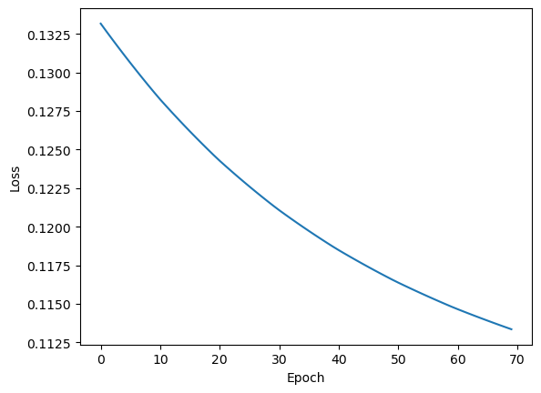

```python
%matplotlib inline
import numpy as np
import matplotlib.pyplot as plt
plt.xlabel("Epoch")
plt.ylabel("Loss")
plt.plot(loss_values)
plt.show()
```

# Authors' rights

Machine Learning with Python course by IBM on Coursera: https://www.coursera.org/learn/machine-learning-with-python/

Completed and modified by Mathilde Marie Duville as part of the IBM Artificial Intelligence Engineering Professional Certificate and corresponding IBM badges. Please, follow the subsequent links to confirm the accreditation:

https://www.coursera.org/account/accomplishments/professional-cert/KSLW773DAATP?utm_source=link&utm_medium=certificate&utm_content=cert_image&utm_campaign=sharing_cta&utm_product=prof

https://www.credly.com/users/mathilde-marie-duville/badges

Author: [Romeo Kienzler](https://linkedin.com/in/romeo-kienzler-089b4557) , [Saeed Aghabozorgi](https://br.linkedin.com/in/walter-gomes-de-amorim-junior-624726121) , [Walter Gomes de Amorim Junior](https://br.linkedin.com/in/walter-gomes-de-amorim-junior-624726121) , Victor Barros Costa

Updated to TF 2.X by [Samaya Madhavan](https://www.linkedin.com/in/samaya-madhavan)

## Change Log

| Date (YYYY-MM-DD) | Version | Changed By | Change Description |
| --- | --- | --- | --- |
| 2020-09-21 | 2.0 | Srishti | Migrated Lab to Markdown and added to course repo in GitLab |
| 2023-10-30 | 2.1 | Vandana | Updated lab instruction |

Copyright © 2018 [Cognitive Class](https://cocl.us/DX0108EN_CC). This notebook and its source code are released under the terms of the MIT License.